# Machine Learning Final Project

Taryn McLaughlin

10/6/2018

```r
setwd("/home/user/datasciencecoursera")
train<-read.csv("pml-training.csv")
test<-read.csv("pml-testing.csv")
```

## Pre-processing the Training Data Set

The training data set is quite large with 19622 observations of 160 variables. If we were to include all variables in our prediction models, the computation time would be extremely long, so we will want to inspect our data set and try to prune it if possible.

### Missing Data

```r
library(dplyr)
library(knitr)
NA_data<-data.frame(sapply(train, function(x){sum(is.na(x))}))
blank_data<-data.frame(sapply(train, function(x){sum(x=="")}))
missing_data<-data.frame(cbind(NA_data, blank_data))
missing_data$variable<-row.names(missing_data)
missing_data<-dplyr::rename(missing_data, N.A = sapply.train..function.x...,
                            Blank = sapply.train..function.x....1)%>%
    filter(N.A>0|Blank>0)%>%
    select(variable, N.A, Blank)
kable(head(missing_data), 8)
```

[output not shown]

```r
train_noNA<-train[ , colSums(is.na(train)) == 0] #sum up the number of NAs in each column
#create new data table that includes only those columns where the sum is equal to zero
train_complete<-train_noNA[ , colSums(train_noNA == "") == 0]
```

### Zero and Near Zero Variance

When building models, we need to be concerned about zero variance and near zero variance predictors. These can skew models and make them unstable, particularly when cross-validation is used. Here we generate the Frequency Ratio and the Percent Unique Values. The first is the ratio of the frequency of the most common value to the second most common value for a feature- this should be close to 1 for well balanced predictors. The second is the number of unique values divided by the total number of entries x100- this will be close to 100 when there are numerous unique predictors and close to 0 when there are only a few.

```r
library(caret)
library(dplyr)
library(knitr)
#Identify the relevant measurements to detect  for each variable
nz<-nearZeroVar(train_complete, saveMetrics= TRUE)
nz<-dplyr::arrange(nz, desc(freqRatio))
kable(head(nz))
```

| freqRatio | percentUnique | zeroVar | nzv |
| --- | --- | --- | --- |
| 87.25641 | 15.7323412 | FALSE | FALSE |
| 65.98305 | 14.8557741 | FALSE | FALSE |
| 52.33846 | 13.5256345 | FALSE | FALSE |
| 47.33005 | 0.0101926 | FALSE | TRUE |
| 33.02913 | 14.6570176 | FALSE | FALSE |
| 15.32283 | 10.1467740 | FALSE | FALSE |

### Correlated Variables

To determine whether any variables are highly correlated with one another, and by extension determine whether we should reduce the dimensions of our data with pre-processing, I have calculated the correlation matrix for all numeric variables in the data set.

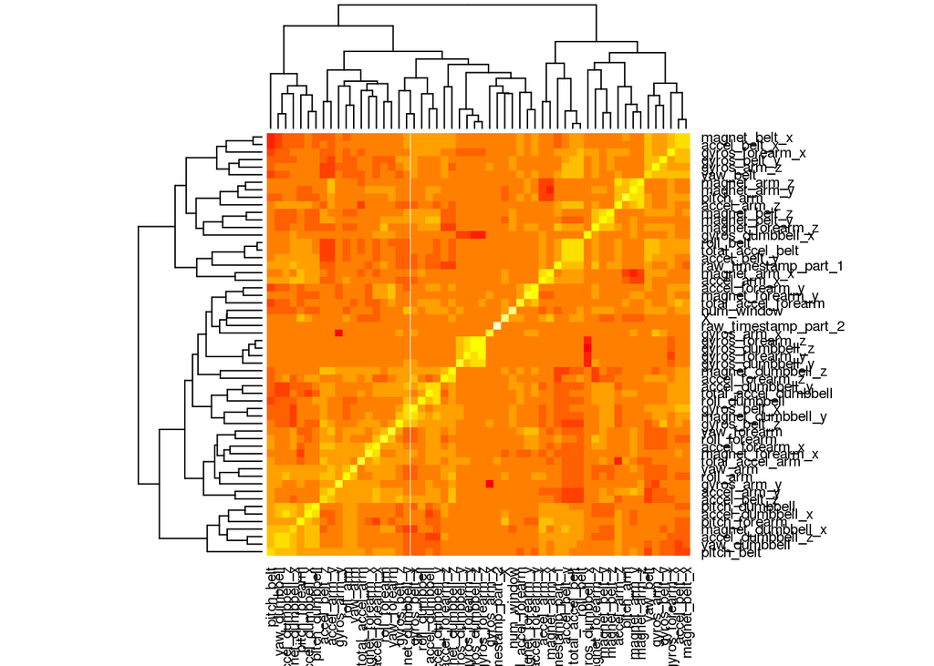

```r
numeric.only <- function(X,...){
    a<-sapply(X, class)
    return(X[a =="numeric"|a=="integer"])}
numbers<-numeric.only(train_complete)
descrCor <-  cor(numbers)
heatmap(descrCor)
```

```r
library(dplyr)
train_complete<-dplyr::select(train_complete, -X)
```

Due to model performance, I will also preemptively subset my data such that y is the outcome variable to use in model training later, x is a table of all complete predictors and x2 is a table of complete predictors that contain only numeric values.

```r
library(dplyr)
y<-train_complete$classe
x<-select(train_complete, -classe)
x2<-x[sapply(x, class) != "factor"]
```

## Training Models

### Training methods

We now specify our training method for all model specifications. We will do 10-fold cross validation to evaluate and improve our models, with no repeats to improve performance time. We will also allow for parallel processing to improve performance time.

```r
library(caret)
fitControl <- trainControl(## 5-fold CV
    method = "cv", #cv: cross validation
    number = 10, #the number of folds
    allowParallel = TRUE
    )
nnetGrid <-  expand.grid(size = seq(from = 1, to = 10, by = 1),
                        decay = seq(from = 0.1, to = 0.5, by = 0.1))
```

### K-nearest Neighbors

Models built using K-nearest Neighbors essentially map all training data points to a “feature space.” To classify new data points, the K nearest training points in the feature spaced are assessed for their categories and a majority wins. So if K is 5 and 3 of the 5 closest points in space are A, the new point is assigned the outcome A.

```r
library(knitr)
library(caret)
library(doParallel)
cluster <- makeCluster(detectCores() - 1)
registerDoParallel(cluster)
set.seed(825)
fit_knn <- train(x2,y,
                  method="knn",
                  trControl = fitControl)
stopCluster(cluster)
registerDoSEQ()
kable(data.frame(fit_knn$resample), caption = "K-Nearest Neighbour Resampling")
```

K-Nearest Neighbour Resampling

| Accuracy | Kappa | Resample |
| --- | --- | --- |
| 0.3226300 | 0.1397320 | Fold02 |
| 0.3243381 | 0.1401184 | Fold01 |
| 0.3039715 | 0.1179234 | Fold03 |
| 0.3302752 | 0.1490095 | Fold06 |
| 0.3170234 | 0.1311199 | Fold05 |
| 0.3192249 | 0.1325332 | Fold04 |
| 0.3100459 | 0.1210371 | Fold07 |
| 0.3312946 | 0.1482521 | Fold10 |
| 0.3226300 | 0.1374811 | Fold09 |
| 0.3154944 | 0.1291102 | Fold08 |

### Support Vector Machine

Support Vector machines also map training data points to a “feature space” and finds a plane that cleanly divides the data between two categories with the most buffer room. New data is then mapped into the model space and categorized based on which side of the plane it falls. It can be expanded to account for more than two outcome categories. It requires non-categorical training features.

```r
library(knitr)
library(caret)
library(doParallel)
cluster <- makeCluster(detectCores() - 1)
registerDoParallel(cluster)
set.seed(825)
fit_svm <- train(x2,y,
                  method="svmLinear",
                  trControl = fitControl,
                  verbose=FALSE)
stopCluster(cluster)
registerDoSEQ()
kable(data.frame(fit_svm$resample), caption = "Support Vector Machine Resampling")
```

Support Vector Machine Resampling

| Accuracy | Kappa | Resample |
| --- | --- | --- |
| 0.7968432 | 0.7415343 | Fold01 |
| 0.7976555 | 0.7429835 | Fold02 |
| 0.8044807 | 0.7518459 | Fold03 |
| 0.7817440 | 0.7226578 | Fold04 |
| 0.7981651 | 0.7432787 | Fold05 |
| 0.7828746 | 0.7240275 | Fold06 |
| 0.7868434 | 0.7288731 | Fold07 |
| 0.7986748 | 0.7442075 | Fold08 |
| 0.7910296 | 0.7343920 | Fold09 |
| 0.8068298 | 0.7544102 | Fold10 |

### Neural Networks

Neural Networks take training data to create a set of “neurons” which take input data, execute some sort of mathematical function on that data, weight the output of the function. The output from each “neuron” is then collected to assign the input data to an outcome value.

```r
library(knitr)
library(caret)
library(doParallel)
cluster <- makeCluster(detectCores() - 1)
registerDoParallel(cluster)
set.seed(825)
fit_nnet <- train(x,y,
                  method="nnet",
                  trControl = fitControl,
                  tuneGrid = nnetGrid,
                  verbose=FALSE)
stopCluster(cluster)
registerDoSEQ()
kable(data.frame(fit_nnet$resample), caption = "NNET Resampling")
```

NNET Resampling

| Accuracy | Kappa | Resample |
| --- | --- | --- |
| 0.2844037 | 0 | Fold08 |
| 0.2844037 | 0 | Fold09 |
| 0.2845487 | 0 | Fold07 |
| 0.2841141 | 0 | Fold03 |
| 0.2844037 | 0 | Fold10 |
| 0.2844037 | 0 | Fold06 |
| 0.2841141 | 0 | Fold01 |
| 0.2844037 | 0 | Fold02 |
| 0.2845487 | 0 | Fold04 |
| 0.2844037 | 0 | Fold05 |

### Random Forest

Random Forest models are essentially bagged tree models. Tree based methods repeatedly divide training data based on features that can distinguish between categories. The sequential divisions essentially form decision “trees” wherein you can take new data with the same features and predict what category it belongs to. Random Forest is an ensemble method wherein many random “trees” are created and combined together to form the random forest used for prediction. Because factor variables can become problematic during the prediction stage using Random Forest, we will use the numeric only set of predictors to train the model.

```r
library(knitr)
library(caret)
library(doParallel)
cluster <- makeCluster(detectCores() - 1)
registerDoParallel(cluster)
set.seed(825)
fit_rf <- train(x2,y,
                 method = "rf",
                 trControl = fitControl,
                 verbose = FALSE)
stopCluster(cluster)
registerDoSEQ()
kable(data.frame(fit_rf$resample), caption = "Random Forest Resampling")
```

Random Forest Resampling

| Accuracy | Kappa | Resample |
| --- | --- | --- |
| 1.0000000 | 1.0000000 | Fold02 |
| 1.0000000 | 1.0000000 | Fold01 |
| 1.0000000 | 1.0000000 | Fold04 |
| 0.9989817 | 0.9987121 | Fold03 |
| 0.9984709 | 0.9980659 | Fold06 |
| 0.9984709 | 0.9980660 | Fold05 |
| 1.0000000 | 1.0000000 | Fold08 |
| 0.9994901 | 0.9993550 | Fold07 |
| 0.9974516 | 0.9967764 | Fold10 |
| 1.0000000 | 1.0000000 | Fold09 |

### Gradient Boosting Machine

Gradient Boosted Models are also based on classification trees, however in this model weak classifiers are combined together to create better classfication. It is still an ensemble method like Random Forests but with the added advantage of giving more “attention” to features that would have had large error rates if left alone.

```r
library(knitr)
library(caret)
library(gbm)
library(doParallel)
cluster <- makeCluster(detectCores() - 1)
registerDoParallel(cluster)
set.seed(825)
fit_gbm <- train(x,y,
                  method="gbm",
                  trControl = fitControl,
                  verbose=FALSE)
stopCluster(cluster)
registerDoSEQ()
kable(data.frame(fit_gbm$resample), caption = "Gradient Boosted Resampling")
```

Gradient Boosted Resampling

| Accuracy | Kappa | Resample |
| --- | --- | --- |
| 0.9964322 | 0.9954872 | Fold06 |
| 0.9943935 | 0.9929094 | Fold09 |
| 0.9954128 | 0.9941983 | Fold05 |
| 0.9989806 | 0.9987107 | Fold08 |
| 0.9969419 | 0.9961320 | Fold02 |
| 0.9964304 | 0.9954846 | Fold04 |
| 0.9959204 | 0.9948398 | Fold07 |
| 0.9959225 | 0.9948430 | Fold10 |
| 0.9969450 | 0.9961363 | Fold01 |
| 0.9959267 | 0.9948482 | Fold03 |

## Evaluating Models

```r
library(knitr)
library(caret)
a<-kable(confusionMatrix.train(fit_knn)$table, caption = "K-Nearest Neighbours")
b<-kable(confusionMatrix.train(fit_svm)$table, caption = "Support Vector Machine")
c<-kable(confusionMatrix.train(fit_nnet)$table, caption = "NNET")
d<-kable(confusionMatrix.train(fit_rf)$table, caption = "Random Forest")
e<-kable(confusionMatrix.train(fit_gbm)$table, caption = "Gradient Boosted Machine")
```

K-Nearest Neighbours

|  | A | B | C | D | E |
| --- | --- | --- | --- | --- | --- |
| A | 14.106615 | 5.616145 | 5.453063 | 3.796759 | 4.494955 |
| B | 3.429824 | 4.087249 | 2.420752 | 2.594027 | 2.976251 |
| C | 4.510244 | 3.521557 | 4.698808 | 2.884517 | 2.945673 |
| D | 3.302416 | 3.220874 | 2.787687 | 4.362450 | 3.251453 |
| E | 3.088370 | 2.904903 | 2.079299 | 2.752013 | 4.714096 |

Using caret, a K-nearest Neighbors model was built with k=5. This model was 0.3196928 accurate and and had a kappa statistic of 0.1346317 in the resampled training data.

Support Vector Machine

|  | A | B | C | D | E |
| --- | --- | --- | --- | --- | --- |
| A | 26.3836510 | 2.5583529 | 1.2842728 | 0.9479156 | 0.9122414 |
| B | 0.5707879 | 13.9078585 | 1.5594741 | 0.6676180 | 2.0181429 |
| C | 0.6013658 | 1.1517684 | 13.7243910 | 1.7939048 | 1.1721537 |
| D | 0.7695444 | 0.3414535 | 0.4331872 | 12.1547243 | 0.9988788 |
| E | 0.1121191 | 1.3912955 | 0.4382836 | 0.8256039 | 13.2810111 |

Using caret, a SVM model was built holding the tuning parameter “C” constant at a value of 1. This model was 0.7945141 accurate and and had a kappa statistic of 0.738821 in the resampled training data.

NNET

|  | A | B | C | D | E |
| --- | --- | --- | --- | --- | --- |
| A | 28.43747 | 19.35073 | 17.43961 | 16.38977 | 18.38243 |
| B | 0.00000 | 0.00000 | 0.00000 | 0.00000 | 0.00000 |
| C | 0.00000 | 0.00000 | 0.00000 | 0.00000 | 0.00000 |
| D | 0.00000 | 0.00000 | 0.00000 | 0.00000 | 0.00000 |
| E | 0.00000 | 0.00000 | 0.00000 | 0.00000 | 0.00000 |

Using caret, a Neural Netowrk model was built with 1 layer, 1 neuron and weight decay = 0.1. This model was 0.2843748 accurate and and had a kappa statistic of 0 in the resampled training data. This model clearly had probblems as it predicted all data as class “A”

Random Forest

|  | A | B | C | D | E |
| --- | --- | --- | --- | --- | --- |
| A | 28.43747 | 0.0050963 | 0.0000000 | 0.0000000 | 0.0000000 |
| B | 0.00000 | 19.3456325 | 0.0254816 | 0.0000000 | 0.0000000 |
| C | 0.00000 | 0.0000000 | 17.4141270 | 0.0305779 | 0.0000000 |
| D | 0.00000 | 0.0000000 | 0.0000000 | 16.3540923 | 0.0050963 |
| E | 0.00000 | 0.0000000 | 0.0000000 | 0.0050963 | 18.3773316 |

Gradient Boosted Machine

|  | A | B | C | D | E |
| --- | --- | --- | --- | --- | --- |
| A | 28.4272755 | 0.0101926 | 0.0000000 | 0.0000000 | 0.0000000 |
| B | 0.0101926 | 19.2793803 | 0.0203853 | 0.0000000 | 0.0000000 |
| C | 0.0000000 | 0.0611558 | 17.3122006 | 0.0305779 | 0.0000000 |
| D | 0.0000000 | 0.0000000 | 0.1070227 | 16.2929365 | 0.0611558 |
| E | 0.0000000 | 0.0000000 | 0.0000000 | 0.0662522 | 18.3212720 |

Using caret, a Gradient Boosted Machine model was built with 150 trees of depth 3 and a learning rate of 0.1. This model was 0.9963306 accurate and and had a kappa statistic of 0.9953589 in the resampled training data.